# POLS 3604

Lecture 16 | Congress and the President

## Plan for Today

- Discuss the president’s role in the legislative arena

## The President, Legislation, and the Constitution

- As we have discussed, Congress was the primary mover of the US government and the legislative arena
- The president was to serve in a secondary role
  - The courts in an even lesser role
- The president was conceptualized as the person who would execute the laws passed by Congress
- This role has changed over time

## The President’s Constituents

- Elected every 4 years
  - House every 2 years
  - Senate every 6
- Can only be elected to two terms
  - 22nd Amendment
- Constituency Size
  - Approximately 330 million people (the entire country)
    - House approximately 750,000
    - Senate approximately 4.5 million (median)
- These differences impact how presidents interact with the legislative process

## The President and the Legislative Process

- Presidents are charged with “faithfully executing the laws”
  - Implementing and administering laws passed by Congress
- However, presidents are given legislative powers in the Constitution
  - Recommending laws / legislation
  - Veto power
  - Appointments
  - Negotiating Treaties

## Presidential Influence in the Legislative Process

- Prioritizing policy / legislative areas
  - By stating priorities, presidents engage in agenda setting
- Vetos
  - Presidents can use the veto to block legislation they disagree with
- Veto threat
  - Presidents can use the veto threat impacts how Congress approaches policy issues

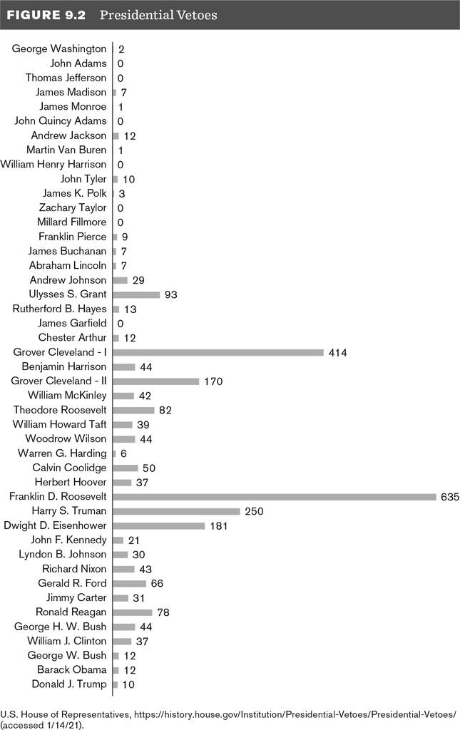

## Presidential Tools to Convince Congress

- “Presidential power is the power to persuade” (Richard Neustadt)
  - Presidents cannot command, they are not kings, they must bargain
- Presidents bargain in many ways
  - Electoral Mandates
    - Try to capitalize on momentum of winning an election by pushing issue areas that they ran on during their campaigns
      - The people have spoke and clearly support the president’s policy objectives
- Going public
  - Bringing issues directly to the people
    - Use the president’s national constituency to pressure members of Congress
  - Public speeches, press conferences, SOTU, social media
- Unilateral actions
  - Signing statements
    - A president’s interpretation of a piece of legislation
  - Executive orders
    - Instruction to executive agencies on how to proceed

## Final Thoughts

- Presidents have cultivated many tools to help them increase their influence in the legislative arena